# *VGG-Net - CNN Architecture*

## *Introduction*

*VGG is an acronym for the Visual Geometric Group from Oxford University and VGG-16 is a network with 16 layers proposed by the Visual Geometric Group. These 16 layers contain the trainable parameters and there are other layers also like the Max pool layer but those do not contain any trainable parameters. This architecture was the 1st runner up of the Visual Recognition Challenge of 2014 i.e. ILSVRC-2014 and was developed by Simonyan and Zisserman.*

*The VGG research group released a series of the convolution network model starting from VGG11 to VGG19. The **main intention of the VGG group on depth was to understand how the depth of convolutional networks affects the accuracy of the models of large-scale image classification and recognition**. The minimum VGG11 has 8 convolutional layers and 3 fully connected layers as compared to the maximum VGG19 which has 16 convolutional layers and the 3 fully connected layers. **The different variations of VGGs are exactly the same in the last three fully connected layers. The overall structure includes 5 sets of convolutional layers, followed by a MaxPool. But the difference is that as the depth increases that is as we move from VGG11 to VGG19 more and more cascaded convolutional layers are added in the five sets of convolutional layers**.*

*This model achieves 92.7% top-5 test accuracy on ImageNet dataset which contains 14 million images belonging to 1000 classes.*

*[Paper - VGG](https://arxiv.org/pdf/1409.1556.pdf)*

### *Network Configurations*

*The below-shown figure is the overall network configuration of different models created by VGG that uses the same principle but only varies in depth.*

[figure not shown]

*From the above comparison table that represents a different network, we can see that as the model moves from simpler to complex the depth of the network is getting increased. This is the best way to solve any problem, means to say, solve the problem using a simpler model and then gradually optimize it by making it complex.*

## *Understanding VGG-16*

[*Network Structure of VGG-16*](http://ethereon.github.io/netscope/#/gist/dc5003de6943ea5a6b8b)

*The input of VGG is set to an **RGB image of 224x244** size. A **3x3 or 1x1 filter** is used, and the **convolution step** is fixed. . There are 3 VGG fully connected layers, which can vary from **VGG11 to VGG19** according to the total number of **convolutional layers + fully connected layers**. The **minimum VGG11** has **8 convolutional layers and 3 fully connected layers**. The maximum **VGG19** has **16 convolutional layers + 3 fully connected layers**. In addition, the VGG network is not followed by a pooling layer behind each convolutional layer, or **a total of 5 pooling layers distributed under different convolutional layers**. The following figure is VGG Structure diagram:*

[figure not shown]

*In the figure above, all the white rectangles represent the convolution layers along with the non-linear activation function which is a rectified linear unit (or ReLU). As can be seen from the figure that there are 13 white and 5 red rectangles i.e there are 13 convolution layers and 5 max-pooling layers. Along with these, there are 3 blue rectangles representing 3 fully connected layers. So, the total number of layers having tunable parameters is 16 of which 13 is for convolution layers and 3 for fully connected layers, thus the name is given as VGG-16. At the output, we have a softmax layer having 1000 outputs per image category in the imagenet dataset.*

*In this architecture, we have started with a very low channel size of 64 and then gradually increased by a factor of 2 after each max-pooling layers, until it reaches 512.*

*The flattened architecture of VGG-16 is as shown below:*

[figure not shown]

*The architecture is very simple. It has got 2 contiguous blocks of 2 convolution layers followed by a max-pooling, then it has 3 contiguous blocks of 3 convolution layers followed by max-pooling, and at last, we have 3 dense layers. The last 3 convolution layers have different depths in different architectures.*

*The important thing to analyze here is that after every max-pooling the size is getting half.*

### *Features of VGG-16 Network*

- *Input Layer* *: It accepts color images as an input with the size 224 x 224 and 3 channels i.e. Red, Green, and Blue.*
- *Convolution Layer* *: The images pass through a stack of convolution layers where every convolution filter has a very small receptive field of 3 x 3 and stride of 1. Every convolution kernel uses row and column padding so that the size of input as well as the output feature maps remains the same or in other words, the resolution after the convolution is performed remains the same.*
- *Max pooling* *: It is performed over a max-pool window of size 2 x 2 with stride equals to 2, which means here max pool windows are non-overlapping windows.*
- *Not every convolution layer is followed by a max pool layer as at some places a convolution layer is following another convolution layer without the max-pool layer in between.*
- *The first two fully connected layers have 4096 channels each and the third fully connected layer which is also the output layer have 1000 channels, one for each category of images in the imagenet database.*
- *The hidden layers have ReLU as their activation function.*

### *Architecture*

*VGG16 contains 16 layers and VGG19 contains 19 layers. A series of VGGs are exactly the same in the last three fully connected layers. The overall structure includes 5 sets of convolutional layers, followed by a MaxPool. The difference is that more and more cascaded convolutional layers are included in the five sets of convolutional layers.*

[figure not shown]

*Each convolutional layer in AlexNet contains only one convolution, and the size of the convolution kernel is 7 *7. In VGGNet, each convolution layer contains 2 to 4 convolution operations. The size of the convolution kernel is 3* 3, the convolution step size is 1, the pooling kernel is 2 * 2, and the step size is 2. The most obvious **improvement of VGGNet is to reduce the size of the convolution kernel and increase the number of convolution layers**.*

*Using multiple convolution layers with smaller convolution kernels instead of a larger convolution layer with convolution kernels can reduce parameters on the one hand, and the author believes that it is equivalent to more non-linear mapping, which increases the Fit expression ability.*

*Two consecutive 3 *3 convolutions are equivalent to a 5* 5 receptive field, and three are equivalent to 7 *7. The **advantages** of __using three 3* 3 convolutions instead of one 7 * 7 **convolution are two:** one, including three ReLu layers instead of one, makes the decision function more discriminative; **and** two, reducing parameters__.*

*The **1 * 1 convolution layer is mainly to increase the non-linearity** of the decision function without affecting the receptive field of the convolution layer. Although the **1 * 1 convolution operation is linear, ReLu adds non-linearity**.*

### *Advantages of having 3 x 3 kernel size*

#### *Mathematically*

*Suppose we have an input of a shape of 224 x 224 with K channels i.e. 224 x 224 x K. We’ll apply convolution with different sizes kernels with stride =1.*

*Case-1: When we have a kernel size of 3 x 3*

```
After the First convolution

N = 224, f = 3, S = 1

Output shape = [(N-f)/S] + 1 = [(224–3)/1] + 1 = 222

After the Second convolution

N = 222, f = 3, S = 1

Output shape = [(N-f)/S] + 1 = [(222–3)/1] + 1 = 220

After the Third convolution

N = 220, f = 3, S = 1

Output shape = [(N-f)/S] + 1 = [(220–3)/1] + 1 = 218

So, after three simultaneous convolutions, we got an output of size 218 x 218 x K

3 3x3 convolutions, using 3 non-linear activation functions, increasing non-linear expression capabilities, making the segmentation plane more separable.
```

*Case-2: When we have a kernel size of 7 x 7*

```
N = 224, f = 7, S = 1

Output shape = [(N-f)/S] + 1 = [(224–7)/1] + 1 = 218

So, after one convolution only we got an output of size 218 x 218 x K
```

*Hence, looking at the above two cases we say that the three 3 × 3 convolution layers have an effective receptive field of 7 × 7.*

#### *Trainable Parameters*

*As we know more the layers of convolution more sharply the features will be extracted from our input as compared to when we have fewer layers. So having 3 x 3 kernel size would lead to much better feature extraction than 7 x 7 kernel size. When we take 3 x 3 kernel size the number of trainable parameters will be 27K² as compared to 7 x 7 kernel size when taken gives 49K² trainable parameters which is 81% more.*

### *Training*

- *The optimization method* *is a stochastic gradient descent SGD + momentum (0.9) with momentum. The batch size is 256.*
- *Regularization* : *L2 regularization is used, and the weight decay is 5e-4. Dropout is after the first two fully connected layers, p = 0.5.*
- *Although it is deeper and has more parameters than the AlexNet network, we speculate that VGGNet can converge in less cycles for two reasons: one, the greater depth and smaller convolutions bring implicit regularization; Second, some layers of pre-training.*
- *Parameter initialization* *: For a shallow A network, parameters are randomly initialized, the weight w is sampled from N (0, 0.01), and the bias is initialized to 0. Then, for deeper networks, first the first four convolutional layers and three fully connected layers are initialized with the parameters of the A network. However, it was later discovered that it is also possible to directly initialize it without using pre-trained parameters.*
- *In order to obtain a 224 * 224 input image, each rescaled image is randomly cropped in each SGD iteration. In order to enhance the data set, the cropped image is also randomly flipped horizontally and RGB color shifted.*

## *Summary of VGGNet Improvement Points*

- *A **smaller 3 * 3 convolution kernel** and a **deeper network** are used.*
- *The stack of **two 3 * 3 convolution kernels** is relative to the field of view of a **5 * 5 convolution kernel**, and the stack of **three 3 *3 convolution kernels is equivalent to the field of view of a 7* 7 convolution kernel**. In this way, there can be **fewer parameters** (3 stacked 3 *3 structures have only 7* 7 structural parameters (3 *3* 3) / (7 * 7) = 55%); on the other hand, they have **more non-linear transformation** which increases the ability of CNN to learn features.*
- *In the convolutional structure of VGGNet, a **1 * 1 convolution kernel** is introduced. Without affecting the input and output dimensions, **non-linear transformation is introduced to increase the expressive power** of the network and reduce the amount of calculation.*
- *During training, first train a simple (low-level) VGGNet A-level network, and then use the weights of the A network to initialize the complex models that follow to speed up the convergence of training.*

### *Difference between VGG-16 and AlexNet*

*As compared to VGG-16 where all the convolution kernels are of the uniform size 3 x 3 with stride as 1, the AlexNet has convolution kernels of variable size like 5 x 5 and 3 x 3.*

*Though AlexNet uses multiple kernels of different sizes, the realization of every convolution kernel of different sizes can be done using multiple 3 x 3 size kernels.*

## *Code Implementation*

*There are 2 ways to perform this task:*

- *By writing the code from scratch*
- *By using the pre-trained VGG16 model trained on imagenet dataset*

### *Getting the Dataset*

```python
!wget -c https://s3.amazonaws.com/content.udacity-data.com/nd089/Cat_Dog_data.zip
```

```
--2020-10-01 15:06:21--  https://s3.amazonaws.com/content.udacity-data.com/nd089/Cat_Dog_data.zip
Resolving s3.amazonaws.com (s3.amazonaws.com)... 52.216.249.54
Connecting to s3.amazonaws.com (s3.amazonaws.com)|52.216.249.54|:443... connected.
HTTP request sent, awaiting response... 200 OK
Length: 580495262 (554M) [application/zip]
Saving to: ‘Cat_Dog_data.zip’

Cat_Dog_data.zip    100%[===================>] 553.60M  16.7MB/s    in 36s

2020-10-01 15:06:58 (15.5 MB/s) - ‘Cat_Dog_data.zip’ saved [580495262/580495262]
```

```python
!unzip -qq Cat_Dog_data.zip
```

### *Writing the VGG16 Architecture Code from Scratch*

```python
# Importing the required libraries
import tensorflow as tf
import keras
import pandas as pd
import numpy as np
from keras.models import Sequential
from keras.layers import Conv2D, MaxPool2D, Flatten, Dense
from keras.preprocessing.image import ImageDataGenerator
from keras.preprocessing import image

from glob import glob
import matplotlib.pyplot as plt

import warnings
warnings.filterwarnings("ignore", category=FutureWarning)
```

```python
# Augmenting the Training dataset

idg = ImageDataGenerator(zoom_range=0.2,
                         shear_range=0.2,
                         horizontal_flip=True,
                         rescale=1/255.0)

training_data = idg.flow_from_directory(r"/content/Cat_Dog_data/train",
                                        target_size = (224, 224))

# Augmenting the Testing dataset

idg = ImageDataGenerator(rescale=1/255.0)

testing_data = idg.flow_from_directory(r"/content/Cat_Dog_data/test",
                                       target_size = (224, 224))
```

```
Found 22500 images belonging to 2 classes.
Found 2500 images belonging to 2 classes.
```

```python
# Initializing a Sequential model
model = Sequential()

# Creating first block- (2 Convolution + 1 Max pool)
model.add(Conv2D(filters= 64, kernel_size= (3,3), strides= (1,1), padding='same', input_shape= (224, 224, 3), activation= 'relu'))
model.add(Conv2D(filters= 64, kernel_size= (3,3), strides= (1,1), padding='same', activation= 'relu'))
model.add(MaxPool2D(pool_size= (2,2), strides=(2,2)))

# Creating second block- (2 Convolution + 1 Max pool)
model.add(Conv2D(filters= 128, kernel_size= (3,3), strides= (1,1), padding='same', activation= 'relu'))
model.add(Conv2D(filters= 128, kernel_size= (3,3), strides= (1,1), padding='same', activation= 'relu'))
model.add(MaxPool2D(pool_size= (2,2), strides=(2,2)))

# Creating third block- (3 Convolution + 1 Max pool)
model.add(Conv2D(filters= 256, kernel_size= (3,3), strides= (1,1), padding='same', activation= 'relu'))
model.add(Conv2D(filters= 256, kernel_size= (3,3), strides= (1,1), padding='same', activation= 'relu'))
model.add(Conv2D(filters= 256, kernel_size= (3,3), strides= (1,1), padding='same', activation= 'relu'))
model.add(MaxPool2D(pool_size= (2,2), strides=(2,2)))

# Creating fourth block- (3 Convolution + 1 Max pool)
model.add(Conv2D(filters= 512, kernel_size= (3,3), strides= (1,1), padding='same', activation= 'relu'))
model.add(Conv2D(filters= 512, kernel_size= (3,3), strides= (1,1), padding='same', activation= 'relu'))
model.add(Conv2D(filters= 512, kernel_size= (3,3), strides= (1,1), padding='same', activation= 'relu'))
model.add(MaxPool2D(pool_size= (2,2), strides=(2,2)))

# Creating fifth block- (3 Convolution + 1 Max pool)
model.add(Conv2D(filters= 512, kernel_size= (3,3), strides= (1,1), padding='same', activation= 'relu'))
model.add(Conv2D(filters= 512, kernel_size= (3,3), strides= (1,1), padding='same', activation= 'relu'))
model.add(Conv2D(filters= 512, kernel_size= (3,3), strides= (1,1), padding='same', activation= 'relu'))
model.add(MaxPool2D(pool_size= (2,2), strides=(2,2)))

# Flattening the pooled image pixels
model.add(Flatten())

# Creating 2 Dense Layers
model.add(Dense(units= 4096, activation='relu'))
model.add(Dense(units= 4096, activation='relu'))

# Creating an output layer
model.add(Dense(units= 2, activation='softmax'))
```

```python
# Getting the summary of the model
model.summary()
```

```
Model: "sequential"
_________________________________________________________________
Layer (type)                 Output Shape              Param #
=================================================================
conv2d (Conv2D)              (None, 224, 224, 64)      1792
_________________________________________________________________
conv2d_1 (Conv2D)            (None, 224, 224, 64)      36928
_________________________________________________________________
max_pooling2d (MaxPooling2D) (None, 112, 112, 64)      0
_________________________________________________________________
conv2d_2 (Conv2D)            (None, 112, 112, 128)     73856
_________________________________________________________________
conv2d_3 (Conv2D)            (None, 112, 112, 128)     147584
_________________________________________________________________
max_pooling2d_1 (MaxPooling2 (None, 56, 56, 128)       0
_________________________________________________________________
conv2d_4 (Conv2D)            (None, 56, 56, 256)       295168
_________________________________________________________________
conv2d_5 (Conv2D)            (None, 56, 56, 256)       590080
_________________________________________________________________
conv2d_6 (Conv2D)            (None, 56, 56, 256)       590080
_________________________________________________________________
max_pooling2d_2 (MaxPooling2 (None, 28, 28, 256)       0
_________________________________________________________________
conv2d_7 (Conv2D)            (None, 28, 28, 512)       1180160
_________________________________________________________________
conv2d_8 (Conv2D)            (None, 28, 28, 512)       2359808
_________________________________________________________________
conv2d_9 (Conv2D)            (None, 28, 28, 512)       2359808
_________________________________________________________________
max_pooling2d_3 (MaxPooling2 (None, 14, 14, 512)       0
_________________________________________________________________
conv2d_10 (Conv2D)           (None, 14, 14, 512)       2359808
_________________________________________________________________
conv2d_11 (Conv2D)           (None, 14, 14, 512)       2359808
_________________________________________________________________
conv2d_12 (Conv2D)           (None, 14, 14, 512)       2359808
_________________________________________________________________
max_pooling2d_4 (MaxPooling2 (None, 7, 7, 512)         0
_________________________________________________________________
flatten (Flatten)            (None, 25088)             0
_________________________________________________________________
dense (Dense)                (None, 4096)              102764544
_________________________________________________________________
dense_1 (Dense)              (None, 4096)              16781312
_________________________________________________________________
dense_2 (Dense)              (None, 2)                 8194
=================================================================
Total params: 134,268,738
Trainable params: 134,268,738
Non-trainable params: 0
_________________________________________________________________
```

```python
# Compiling the model
model.compile(optimizer='adam', loss='binary_crossentropy', metrics=['accuracy'])
```

```python
# Fitting the model
result = model.fit_generator(steps_per_epoch=100,
                             generator=training_data,
                             verbose=1,
                             validation_data=testing_data,
                             epochs=50)
```

[output not shown]

### *Using the pre-trained VGG16 model trained on `imagenet` dataset*

```python
# The entire network is present under VGG16 feature extractor
from keras.applications.vgg16 import VGG16

model_vgg = VGG16(weights='imagenet', include_top=False, input_shape= (224,224,3))

# include_top: Whether to include the 3 fully-connected layers at the top of the network.
# weights: 'imagenet' (pre-training on ImageNet), or the path to the weights file to be loaded.
```

```
Downloading data from https://storage.googleapis.com/tensorflow/keras-applications/vgg16/vgg16_weights_tf_dim_ordering_tf_kernels_notop.h5
```

```python
# Preventing 13 Convolution layers to be trained
for layer in model_vgg.layers:
    layer.trainable = False
```

```python
training_data.image_shape
```

```
(224, 224, 3)
```

```python
# Creating Model
model = keras.Sequential()

# Adding pre-trained model layers
model.add(model_vgg)

# Flattening the image pixels
model.add(Flatten())

# Adding 2 dense layers with 4096 neurons
model.add(Dense(4096, activation='relu'))
model.add(Dense(4096, activation='relu'))

# Adding an output layer with 2 neurons
model.add(Dense(2, activation='sigmoid'))

# Getting the structure of our model
model.summary()
```

```
Model: "sequential_1"
_________________________________________________________________
Layer (type)                 Output Shape              Param #
=================================================================
vgg16 (Functional)           (None, 7, 7, 512)         14714688
_________________________________________________________________
flatten_1 (Flatten)          (None, 25088)             0
_________________________________________________________________
dense_3 (Dense)              (None, 4096)              102764544
_________________________________________________________________
dense_4 (Dense)              (None, 4096)              16781312
_________________________________________________________________
dense_5 (Dense)              (None, 2)                 8194
=================================================================
Total params: 134,268,738
Trainable params: 119,554,050
Non-trainable params: 14,714,688
_________________________________________________________________
```

```python
# from keras import optimizers
# sgd = optimizers.SGD(lr=0.01, decay=1e-6, momentum=0.9)
# model.compile(loss='binary_crossentropy', optimizer=sgd, metrics=['accuracy'])

# Compiling the model
model.compile(optimizer='adam', loss='binary_crossentropy', metrics=['accuracy'])
```

```python
# Fitting the model
result = model.fit_generator(steps_per_epoch=100,
                             generator=training_data,
                             verbose=1,
                             validation_data=testing_data,
                             epochs=5)
```

[output not shown]

```python
# from keras.callbacks import ModelCheckpoint
# from keras.callbacks import ReduceLROnPlateau

# lr_reducer = ReduceLROnPlateau(factor=np.sqrt(0.1), cooldown=0,
#                                patience=5, min_lr=0.5e-6)

# checkpoint = ModelCheckpoint(filepath='mymodel.h5', verbose=1, save_best_only=True)

# callbacks = [checkpoint, lr_reducer, lr_scheduler]

# model.fit_generator(train_set,
#                     validation_data=test_set,
#                     epochs=10,
#                     steps_per_epoch=5,
#                     validation_steps=32,
#                     callbacks=callbacks,
#                     verbose=1)
```

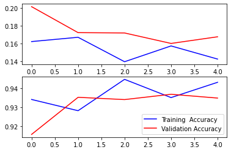

```python
# After successful training, we will visualize its performance.

import matplotlib.pyplot as plt
# Plotting the training and validation loss

f,ax=plt.subplots(2,1) #Creates 2 subplots under 1 column

# Assigning the first subplot to graph training loss and validation loss
ax[0].plot(result.history['loss'],color='b',label='Training Loss')
ax[0].plot(result.history['val_loss'],color='r',label='Validation Loss')

# Plotting the training accuracy and validation accuracy
ax[1].plot(result.history['accuracy'],color='b',label='Training  Accuracy')
ax[1].plot(result.history['val_accuracy'],color='r',label='Validation Accuracy')

plt.legend()
```

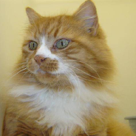

```python
# Load the testing image
test_img = image.load_img(r"/content/Cat_Dog_data/test/cat/cat.10009.jpg", target_size=(224,224))
test_img
```

```python
# Converting image to array
test_img = np.asarray(test_img)

# Expanding the dimensions
test_img = np.expand_dims(test_img, axis=0)
```

```python
# Predicting the loaded image
output = model.predict(test_img)

# Condition of checking the label of the loaded or tested image
if output[0][0] > output[0][1]:
    print("Cat")
else:
    print("Dog")
```

```
Cat
```